# R Notebook

Importing the libraries

```r
library(ggplot2)
library(pals)
library(knitr)
library(cowplot)
library(betareg)
library(tidyverse)
```

Loading the data

```r
name_of_data_note <- 'load_the_data.Rmd'
name_of_data_script <- 'load_the_data.R'
```

```r
knit(name_of_data_note, tangle=TRUE)
source(name_of_data_script)
```

```r
output_dir=paste(getwd(),'/tables',sep='')
if (!dir.exists(output_dir)) {dir.create(output_dir)}

plots_dir=paste(getwd(),'/figures',sep='')
if (!dir.exists(plots_dir)) {dir.create(plots_dir)}
```

```r
# Add a variable that has the ARG normalized by 16s counts but times 1000
semar_info_frame <- semar_info_frame %>% mutate(res_count_kbac_norm = res_count_bac_norm*1000)
```

```r
#use matched clinical data
clin_vars <- c('cl_R_AP','cl_R_FQ','cl_R_3GC','cl_R_AG','cl_R_MAR')

clin_data_ecdc <- readxl::read_excel('data/ecdc_data.xlsx', sheet='matched') %>%
  dplyr::select(all_of(clin_vars), Country)

semar_info_frame <- semar_info_frame %>%dplyr::select(!all_of(clin_vars)) %>%  left_join(clin_data_ecdc, by='Country')
```

Overview of the data

## Total ARG abundance

Plot both sequencing relative abundance. The sequencing data is normalized with the estimated 16S counts.

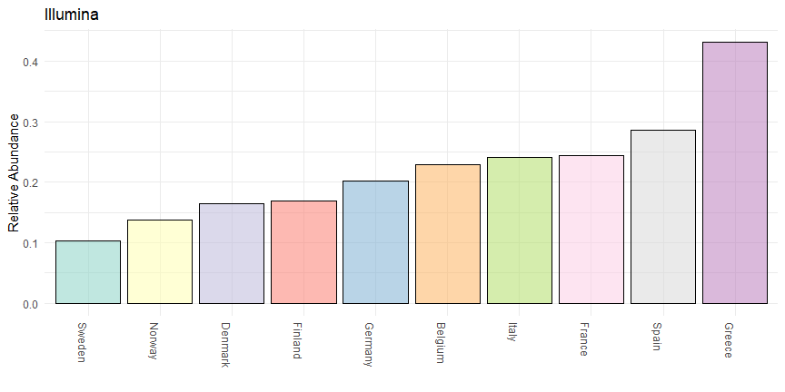

```r
cl_order <- order(semar_info_frame$res_count_bac_norm)
cl_order_names <- semar_info_frame$Country[cl_order]

 arg.bac.norm <- ggplot(semar_info_frame, aes(x = Country, y = res_count_kbac_norm,fill = Country, alpha = 0.5)) +
    geom_bar(stat="identity",colour="black")+ scale_fill_brewer(type='qual',palette=8)  +
    theme_minimal() + guides(fill = FALSE, alpha = FALSE) + theme(axis.text.x = element_text(angle = 270,hjust=0)) +
    labs(y = "Relative Abundance", x = "",title="Illumina")

 arg.bac.norm$data$Country <- factor(arg.bac.norm$data$Country, levels = cl_order_names) # Comment this if order by country name


print(arg.bac.norm)
```

Save the above figure

```r
ggsave("figures/arg_relative_abundance.svg", arg.bac.norm, height=6,width=11)
```

## ARG class distribution

```r
# Create a phylsoeq with arg classes from sequencing data
ps_to_use <- ps_args_bac_norm
taxGlomRank = "Class"
ps_arg_class <- tax_glom(ps_to_use, taxrank = taxGlomRank)
taxa_names(ps_arg_class) <- tax_table(ps_arg_class)[,1]

# Normalize by total ARG abundance
ps_arg_class_norm <- transform_sample_counts(ps_arg_class,function(x) x/sum(x))
```

```r
ps_tmp <- ps_arg_class_norm
sample_names(ps_tmp) <- sample_data(ps_tmp)$Country
write.table(data.frame(otu_table(ps_tmp)),'figures/illumina_arg_class_distribution.txt',sep='\t')
```

Create the relative abundance plot

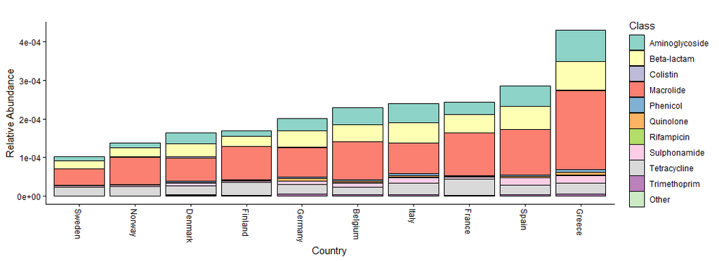

```r
# ---- Illumina data ----- #
# Use only the 10 most abundant classes

#Counts
ps_arg_class_norm <- transform_sample_counts(ps_arg_class,function(x) x/1)


ps_to_use <- ps_arg_class_norm
num_species = 11
top_names = names(sort(taxa_sums(ps_to_use), TRUE)[1:num_species])
ps2=prune_taxa(top_names,ps_to_use)


ps_to_use <- ps2

# Create the figure

#data prep
df_otu_top_10 <- as.data.frame(as.matrix(ps_to_use@otu_table)) %>%
  rownames_to_column()

df_otu_top_10_long <-  df_otu_top_10 %>% pivot_longer(names_to = 'Sample', values_to = 'abundance', cols = starts_with('P'))


top_10_sum <- as.data.frame(t(df_otu_top_10 %>%
  summarise(across(where(is.numeric), ~ sum(.x, na.rm = TRUE))))) %>%
  rownames_to_column() %>%
  left_join(semar_info_frame, by=c('rowname'='Sample')) %>%
  mutate(Other=res_count_bac_norm-V1)

top_10_other <- top_10_sum %>% select(Sample=rowname, 'abundance'=Other) %>%
  mutate(rowname='Other')

tot_abund_plot <- rbind(df_otu_top_10_long, top_10_other) %>%
  left_join(semar_info_frame %>% select(Country, Sample), by='Sample') %>%
  arrange(abundance) %>%
  mutate(Class=factor(rowname, levels=c("Aminoglycoside","Beta-lactam", "Colistin", "Macrolide","Phenicol" ,
                                        "Quinolone",      "Rifampicin", "Sulphonamide",   "Tetracycline",   "Trimethoprim","Other"))) %>%
  filter(!is.na(Class))

#plot
abundance_p2 <- ggplot(tot_abund_plot, aes(x = reorder(Country, abundance), y = abundance, fill = Class)) +
  geom_bar(stat="identity",colour="black", linewidth=.1)+
  scale_fill_brewer(type='qual',palette=8, name='Class')  +
  theme_classic() +
  theme(axis.text.x = element_text(angle = 270,vjust=0.5, hjust=0),
        legend.position = 'right') +
  labs(y = "Relative Abundance", x = "Country",title="")


print(abundance_p2)
```

Save the above figure

```r
ggsave("figures/fig 1_arg_class_distributions.png", abundance_p2, height=6,width=8)
ggsave("figures/fig 1_arg_class_distributions.svg", abundance_p2, height=6,width=8)
```

# Predictions

## Total ARGs

### Predictions

Loop over all predictors and the four response (clinical resistance to AP, FQ, 3GC and AG) variables.

So the predictors used here are:

Isolates: “wwtp_R_AP”,“wwtp_R_FQ”,“wwtp_R_3GC”,“wwtp_R_AG”, “wwtp_R_MAR” Illumina normalized total ARG count (disinfectants not included): “res_count_kbac_norm”

Illumina normalized intI1: “intI1_count_bac_norm”

```r
prediction_frame <- data.frame()
response_variables <- c("cl_R_AP","cl_R_FQ","cl_R_3GC","cl_R_AG")
predict_frame_colnames <- c("AP_Rsquare","AP_pval","FQ_Rsquare","FQ_pval","3GC_Rsquare","3GC_pval","AG_Rsquare","AG_pval")


num_response_variables = length(response_variables)
illumina_total_arg <- c()


predictors <- c("wwtp_R_AP","wwtp_R_FQ","wwtp_R_3GC","wwtp_R_AG","wwtp_R_MAR","res_count_kbac_norm","intI1_count_bac_norm")

num_predictors <- length(predictors)

for (pr in 1:num_predictors) {
  j = 1
  illumina_total_arg <- c()
  for (i in 1:num_response_variables) {
    tmp <- summary(betareg(paste(response_variables[i]," ~ ",predictors[pr]), data=semar_info_frame))
    illumina_total_arg[j] <- tmp$pseudo.r.squared
    j = j+1
    illumina_total_arg[j] <- tmp$coefficients$mean[2,4]
    j = j+1
  }
  prediction_frame <- rbind(prediction_frame,illumina_total_arg)

}
colnames(prediction_frame) <- predict_frame_colnames
rownames(prediction_frame) <- predictors
prediction_frame_total <- prediction_frame
print(prediction_frame)
```

|  | AP_Rsquare | AP_pval | FQ_Rsquare | FQ_pval | 3GC_Rsquare | 3GC_pval | AG_Rsquare | AG_pval |
| --- | --- | --- | --- | --- | --- | --- | --- | --- |
| wwtp_R_AP | 6.650766e-01 | 9.589696e-06 | 0.4930534016 | 5.375097e-03 | 0.3712113661 | 0.04913038 | 0.46728099 | 8.987806e-03 |
| wwtp_R_FQ | 4.984164e-01 | 1.789969e-03 | 0.5585529220 | 1.711637e-03 | 0.3057454059 | 0.09906047 | 0.59144897 | 1.317486e-03 |
| wwtp_R_3GC | 2.831013e-05 | 9.866501e-01 | 0.0008983863 | 9.222596e-01 | 0.0001290152 | 0.97193662 | 0.02663923 | 5.875172e-01 |
| wwtp_R_AG | 1.273668e-01 | 2.374756e-01 | 0.1084748347 | 2.431516e-01 | 0.0418159095 | 0.54885679 | 0.14559729 | 1.712604e-01 |
| wwtp_R_MAR | 5.995261e-01 | 1.029393e-04 | 0.5058514470 | 3.882258e-03 | 0.3351321235 | 0.07980212 | 0.49346926 | 5.717474e-03 |
| res_count_kbac_norm | 4.786271e-01 | 2.091367e-03 | 0.4475051124 | 7.677955e-03 | 0.4357482391 | 0.01528633 | 0.59369188 | 1.165263e-04 |
| intI1_count_bac_norm | 6.210977e-01 | 5.563179e-05 | 0.7364094465 | 2.377936e-06 | 0.5860069600 | 0.00239543 | 0.76629572 | 8.157648e-08 |

```r
NA
```

## Corresponding ARGs

Two functions that summarizes a given ARG class counts and merges it to a given data frame.

```r
get_class_counts_sample=function(physeq,metaframe) {
  # This function merge the counts by Sample names
  tmp_otus <- otu_table(physeq)
  tmp_res_count <- apply(tmp_otus,2,sum)

  tmp_res_count_frame <- data.frame(tmp_res_count)
  tmp_res_count_frame <- tmp_res_count_frame %>% mutate(Sample = rownames(tmp_res_count_frame))
  tmp_frame <- merge(metaframe, tmp_res_count_frame, by="Sample")

  rownames(tmp_frame) <- tmp_frame$Sample
  return(tmp_frame)
  }

get_class_counts_country=function(physeq,metaframe) {
  # This function merge the counts by Country names
  tmp_otus <- otu_table(physeq)
  tmp_res_count <- apply(tmp_otus,2,sum)

  tmp_res_count_frame <- data.frame(tmp_res_count)
  tmp_res_count_frame <- tmp_res_count_frame %>% mutate(Country = rownames(tmp_res_count_frame))
  tmp_frame <- merge(metaframe, tmp_res_count_frame, by="Country")

  rownames(tmp_frame) <- tmp_frame$Country
  return(tmp_frame)
  }
```

### Illumina corresponding ARGs

Load files containing names of ARGs that gives 3rg gen cephalosporin and AP resistance

```r
ceph_file <- 'data/ceph_args.txt'
ap_file <- 'data/ap_args.txt'

ceph_args_list <- read_delim(ceph_file,'\t')
ap_args_list <- read_delim(ap_file,'\t')
```

Extract counts for repsective ARG class from the Illumina data

```r
ps_to_use <- ps_args_bac_norm
sample_names(ps_to_use) <- sample_data(ps_to_use)$Country

updated_info_frame <- data.frame(sample_data(ps_to_use))

# Extract the AP resistance assays
ps_args_beta = subset_taxa(ps_to_use , cl_90 %in% ap_args_list$cl_90)

updated_info_frame <- get_class_counts_country(ps_args_beta,updated_info_frame)
updated_info_frame <- updated_info_frame %>% dplyr::rename(ap_res_count=tmp_res_count)

# Extract the ceph resistance assays
ps_args_beta = subset_taxa(ps_to_use , cl_90 %in% ceph_args_list$cl_90)

updated_info_frame <- get_class_counts_country(ps_args_beta,updated_info_frame)
updated_info_frame <- updated_info_frame %>% dplyr::rename(ceph_res_count=tmp_res_count)

# Extract AG resistance assays
ps_args_beta = subset_taxa(ps_to_use , Class %in% "Aminoglycoside")

updated_info_frame <- get_class_counts_country(ps_args_beta,updated_info_frame)
updated_info_frame <- updated_info_frame %>% dplyr::rename(ag_res_count=tmp_res_count)

# Extract quinolone resistance assays
ps_args_beta = subset_taxa(ps_to_use , Class %in% "Quinolone")

updated_info_frame <- get_class_counts_country(ps_args_beta,updated_info_frame)
updated_info_frame <- updated_info_frame %>% dplyr::rename(quin_res_count=tmp_res_count)

#saving for model runs
tot_ab_class_args <- updated_info_frame
```

Create data frame for Illumina data vs clinical resistance, then generate the figure

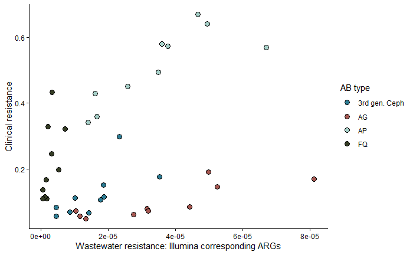

```r
tmp_frame <- updated_info_frame

AP <- tmp_frame %>% dplyr::select(ap_res_count, cl_R_AP)
colnames(AP) <- c("wwtp","clinical")
FQ <- tmp_frame %>% dplyr::select(quin_res_count, cl_R_FQ)
colnames(FQ) <- c("wwtp","clinical")
ceph <- tmp_frame %>% dplyr::select(ceph_res_count, cl_R_3GC)
colnames(ceph) <- c("wwtp","clinical")
AG <- tmp_frame %>% dplyr::select(ag_res_count, cl_R_AG)
colnames(AG) <- c("wwtp","clinical")


data <- rbind(AP, FQ, ceph, AG)
data$group <- rep(c("AP", "FQ", "3rd gen. Ceph","AG"), c(nrow(AP), nrow(FQ), nrow(ceph),nrow(AG)))


# Create the figure for Illumina total ARGs vs clinical resistance
wwtp.clin.corr.illum <- ggplot(data, aes(x = wwtp, y = clinical, fill = group)) +
  geom_point(pch=21, size=3)+
  scale_fill_manual(values = c("#2c7c94","#a65852","#a6d0c8","#343c24","#c4aa23"))+
  theme_classic()+labs(x="Wastewater resistance: Illumina corresponding ARGs", y="Clinical resistance",fill="AB type") #+ scale_x_log10()
wwtp.clin.corr.illum
```

predictions

```r
prediction_frame <- prediction_frame_total
old_names <- rownames(prediction_frame)
response_variables <- c("cl_R_AP","cl_R_FQ","cl_R_3GC","cl_R_AG")
predict_frame_colnames <- c("AP_Rsquare","AP_pval","FQ_Rsquare","FQ_pval","3GC_Rsquare","3GC_pval","AG_Rsquare","AG_pval")


num_response_variables = length(response_variables)
illumina_total_arg <- c()
predictors <- c("ap_res_count","quin_res_count","ceph_res_count","ag_res_count")
num_predictors <- length(predictors)

for (pr in 1:num_predictors) {
  j = 1
  illumina_total_arg <- c()
  for (i in 1:num_response_variables) {
    tmp <- summary(betareg(paste(response_variables[i]," ~ ",predictors[pr]), data=updated_info_frame))
    illumina_total_arg[j] <- tmp$pseudo.r.squared
    j = j+1
    illumina_total_arg[j] <- tmp$coefficients$mean[2,4]
    j = j+1
  }
  prediction_frame <- rbind(prediction_frame,illumina_total_arg)

}

new_row_names <- c(old_names,predictors)
rownames(prediction_frame) <- new_row_names
prediction_frame_corr <- prediction_frame
print(prediction_frame)
```

|  | AP_Rsquare | AP_pval | FQ_Rsquare | FQ_pval | 3GC_Rsquare | 3GC_pval | AG_Rsquare | AG_pval |
| --- | --- | --- | --- | --- | --- | --- | --- | --- |
| wwtp_R_AP | 6.650766e-01 | 9.589696e-06 | 0.4930534016 | 5.375097e-03 | 0.3712113661 | 0.0491303835 | 0.46728099 | 8.987806e-03 |
| wwtp_R_FQ | 4.984164e-01 | 1.789969e-03 | 0.5585529220 | 1.711637e-03 | 0.3057454059 | 0.0990604708 | 0.59144897 | 1.317486e-03 |
| wwtp_R_3GC | 2.831013e-05 | 9.866501e-01 | 0.0008983863 | 9.222596e-01 | 0.0001290152 | 0.9719366172 | 0.02663923 | 5.875172e-01 |
| wwtp_R_AG | 1.273668e-01 | 2.374756e-01 | 0.1084748347 | 2.431516e-01 | 0.0418159095 | 0.5488567868 | 0.14559729 | 1.712604e-01 |
| wwtp_R_MAR | 5.995261e-01 | 1.029393e-04 | 0.5058514470 | 3.882258e-03 | 0.3351321235 | 0.0798021194 | 0.49346926 | 5.717474e-03 |
| res_count_kbac_norm | 4.786271e-01 | 2.091367e-03 | 0.4475051124 | 7.677955e-03 | 0.4357482391 | 0.0152863287 | 0.59369188 | 1.165263e-04 |
| intI1_count_bac_norm | 6.210977e-01 | 5.563179e-05 | 0.7364094465 | 2.377936e-06 | 0.5860069600 | 0.0023954297 | 0.76629572 | 8.157648e-08 |
| ap_res_count | 6.699722e-01 | 4.300805e-06 | 0.7092399683 | 1.283930e-05 | 0.6323957600 | 0.0006694447 | 0.75709821 | 8.138892e-08 |
| quin_res_count | 2.133405e-01 | 9.987302e-02 | 0.3639128815 | 2.845033e-02 | 0.3388449045 | 0.0466650853 | 0.32890151 | 3.032317e-02 |
| ceph_res_count | 4.476182e-01 | 4.144567e-03 | 0.6115627728 | 3.126926e-04 | 0.5509377755 | 0.0024427178 | 0.62574982 | 3.962347e-05 |

[output cut: 1 more lines]

# Top ten in Ecoli

## Illumina data

### Total top ten

```r
top_ten_unique <- c("sul2_clust1_c90",
"aph(3__)-Ib_clust1_c90",
"aph(6)-Id_clust1_c90",
"tet(A)_clust1_c90",
"blaTEM-115_clust1_c90",
"sul1_clust1_c90",
"aadA22_clust1_c90",
"tet(B)_clust1_c90",
"mph(A)_clust2_c90",
"blaCTX-M-186_clust1_c90")
```

```r
ps_to_use <- ps_args_bac_norm
sample_names(ps_to_use) <- sample_data(ps_to_use)$Country

updated_info_frame <- data.frame(sample_data(ps_to_use))

ps_args_beta = subset_taxa(ps_to_use , cl_90 %in% top_ten_unique)

updated_info_frame <- get_class_counts_country(ps_args_beta,updated_info_frame)
updated_info_frame <- updated_info_frame %>% dplyr::rename(top_ten_illum=tmp_res_count)
```

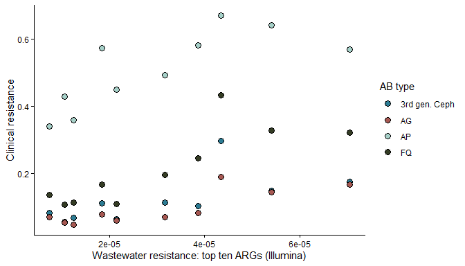

```r
tmp_frame <- updated_info_frame

AP <- tmp_frame %>% dplyr::select(top_ten_illum, cl_R_AP)
colnames(AP) <- c("wwtp","clinical")
FQ <- tmp_frame %>% dplyr::select(top_ten_illum, cl_R_FQ)
colnames(FQ) <- c("wwtp","clinical")
ceph <- tmp_frame %>% dplyr::select(top_ten_illum, cl_R_3GC)
colnames(ceph) <- c("wwtp","clinical")
AG <- tmp_frame %>% dplyr::select(top_ten_illum, cl_R_AG)
colnames(AG) <- c("wwtp","clinical")


data <- rbind(AP, FQ, ceph, AG)
data$group <- rep(c("AP", "FQ", "3rd gen. Ceph","AG"), c(nrow(AP), nrow(FQ), nrow(ceph),nrow(AG)))


# Create the figure for Illumina total ARGs vs clinical resistance
wwtp.clin.top.illum <- ggplot(data, aes(x = wwtp, y = clinical, fill = group)) +
  geom_point(pch=21, size=3)+
  scale_fill_manual(values = c("#2c7c94","#a65852","#a6d0c8","#343c24","#c4aa23"))+
  theme_classic()+labs(x="Wastewater resistance: top ten ARGs (Illumina)", y="Clinical resistance",fill="AB type") #+ scale_x_log10()
wwtp.clin.top.illum
```

### Top ten corresponding ARG

```r
top_ten_AG <- c("aph(3__)-Ib_clust1_c90","aph(6)-Id_clust1_c90","aadA22_clust1_c90","aadA5_clust1_c90",
                "aph(3_)-Ia_clust1_c90","aac(3)-IIc_clust1_c90","aadA2b_clust1_c90","aac(3)-IVa_clust1_c90","aph(4)-Ia_clust1_c90","aac(3)-VIa_clust1_c90"
)

top_ten_beta <- c("blaTEM-115_clust1_c90","blaCTX-M-186_clust1_c90","blaCTX-M-21_clust1_c90","blaOXA-534_clust1_c90","blaCMY-129_clust1_c90",
                  "blaNDM-9_clust1_c90","blaOXA-514_clust1_c90","blaSHV-78_clust1_c90","blaHERA-5_clust1_c90","blaOXA-16_clust1_c90"
)


top_ten_FQ <- c("qnrS3_clust1_c90","qnrB65_clust1_c90","OqxA_clust1_c90","OqxB_clust1_c90","qepA1_clust1_c90",
                "qnrS6_clust1_c90","qnrA3_clust1_c90","qnrD2_clust1_c90","qnrVC7_clust1_c90","qepA3_clust1_c90"
)

top_ten_AP <- c("blaTEM-115_clust1_c90","blaCTX-M-186_clust1_c90","blaCTX-M-21_clust1_c90","blaOXA-534_clust1_c90",
                "blaCMY-129_clust1_c90","blaNDM-9_clust1_c90","blaOXA-514_clust1_c90","blaSHV-78_clust1_c90","blaHERA-5_clust1_c90","blaOXA-16_clust1_c90"
)

top_ten_ceph <- c("blaCTX-M-186_clust1_c90","blaCTX-M-21_clust1_c90","blaCMY-129_clust1_c90","blaNDM-9_clust1_c90",
                  "blaSHV-78_clust1_c90","blaOXA-16_clust1_c90","blaKPC-9_clust1_c90","blaDHA-17_clust1_c90","blaKPC-12_clust1_c90","blaTEM-115_clust1_c90"
)
```

```r
ps_to_use <- ps_args_bac_norm

sample_names(ps_to_use) <- sample_data(ps_to_use)$Country

updated_info_frame <- data.frame(sample_data(ps_to_use))

# AP
ps_args_beta = subset_taxa(ps_to_use , cl_90 %in% top_ten_AP)
updated_info_frame <- get_class_counts_country(ps_args_beta,updated_info_frame)
updated_info_frame <- updated_info_frame %>% dplyr::rename(ap_res_count=tmp_res_count)

# 3rd gen cephalosporins
ps_args_beta = subset_taxa(ps_to_use , cl_90 %in% top_ten_ceph)
updated_info_frame <- get_class_counts_country(ps_args_beta,updated_info_frame)
updated_info_frame <- updated_info_frame %>% dplyr::rename(ceph_res_count=tmp_res_count)

# AG
ps_args_beta = subset_taxa(ps_to_use , cl_90 %in% top_ten_AG)
updated_info_frame <- get_class_counts_country(ps_args_beta,updated_info_frame)
updated_info_frame <- updated_info_frame %>% dplyr::rename(ag_res_count=tmp_res_count)

# FQ
ps_args_beta = subset_taxa(ps_to_use , cl_90 %in% top_ten_FQ)
updated_info_frame <- get_class_counts_country(ps_args_beta,updated_info_frame)
updated_info_frame <- updated_info_frame %>% dplyr::rename(quin_res_count=tmp_res_count)

# Total top ten
ps_args_beta = subset_taxa(ps_to_use , cl_90 %in% top_ten_unique)
updated_info_frame <- get_class_counts_country(ps_args_beta,updated_info_frame)
updated_info_frame <- updated_info_frame %>% dplyr::rename(top_ten_illum=tmp_res_count)

#Top ten ARGs
tmp_info_frame <- updated_info_frame %>% dplyr::rename(top_ten_ap = ap_res_count, top_ten_ceph = ceph_res_count, top_ten_FQ=quin_res_count, top_ten_ag=ag_res_count, top_ten_args = top_ten_illum)
```

Plot the data

```r
tmp_frame <- updated_info_frame

AP <- tmp_frame %>% dplyr::select(ap_res_count, cl_R_AP)
colnames(AP) <- c("wwtp","clinical")
FQ <- tmp_frame %>% dplyr::select(quin_res_count, cl_R_FQ)
colnames(FQ) <- c("wwtp","clinical")
ceph <- tmp_frame %>% dplyr::select(ceph_res_count, cl_R_3GC)
colnames(ceph) <- c("wwtp","clinical")
AG <- tmp_frame %>% dplyr::select(ag_res_count, cl_R_AG)
colnames(AG) <- c("wwtp","clinical")

data <- rbind(AP, FQ, ceph, AG)
data$group <- rep(c("AP", "FQ", "3GC","AG"), c(nrow(AP), nrow(FQ), nrow(ceph),nrow(AG)))
```

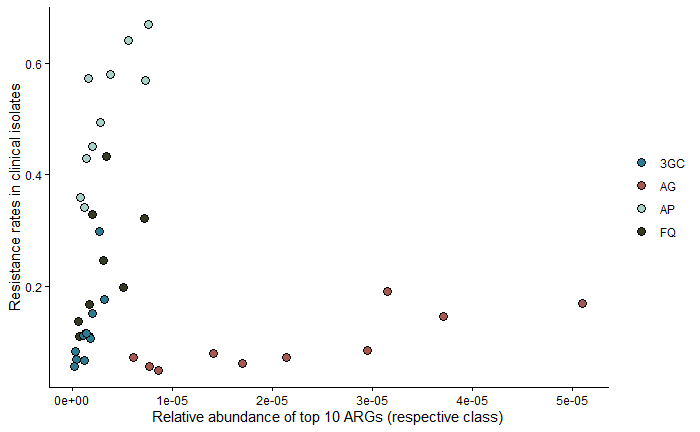

```r
wwtp.top.sep.plot <- ggplot(data, aes(x = wwtp, y = clinical, fill = group)) +
  geom_point(pch=21, size=3)+
  scale_fill_manual(values = c("#2c7c94","#a65852","#a6d0c8","#343c24"))+
  theme_classic()+labs(x="Relative abundance of top 10 ARGs (respective class)", y="Resistance rates in clinical isolates",fill="AB type")+
  theme(legend.title = element_blank())#+scale_x_log10()
wwtp.top.sep.plot
```

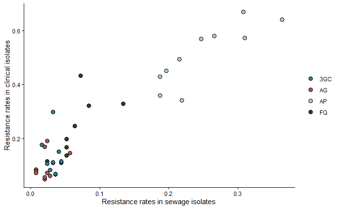

```r
#sewage clinical plot
tmp_frame <- updated_info_frame

AP <- tmp_frame %>% dplyr::select(wwtp_R_AP, cl_R_AP)
colnames(AP) <- c("wwtp","clinical")
FQ <- tmp_frame %>% dplyr::select(wwtp_R_FQ, cl_R_FQ)
colnames(FQ) <- c("wwtp","clinical")
ceph <- tmp_frame %>% dplyr::select(wwtp_R_3GC, cl_R_3GC)
colnames(ceph) <- c("wwtp","clinical")
AG <- tmp_frame %>% dplyr::select(wwtp_R_AG, cl_R_AG)
colnames(AG) <- c("wwtp","clinical")

data <- rbind(AP, FQ, ceph, AG)
data$group <- rep(c("AP", "FQ", "3GC","AG"), c(nrow(AP), nrow(FQ), nrow(ceph),nrow(AG)))

wwtp.sew.clin <- ggplot(data, aes(x = wwtp, y = clinical, fill = group)) +
  geom_point(pch=21, size=3)+
  scale_fill_manual(values = c("#2c7c94","#a65852","#a6d0c8","#343c24"))+
  theme_classic()+labs(x="Resistance rates in sewage isolates", y="Resistance rates in clinical isolates",fill="AB type")+
  theme(legend.title = element_blank())#+scale_x_log10()
wwtp.sew.clin
```

```r
NA
NA
```

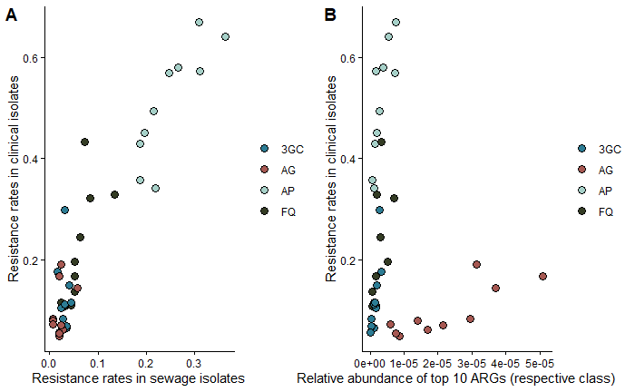

```r
fig2 <- plot_grid(wwtp.sew.clin,wwtp.top.sep.plot, nrow=1, ncol=2,labels="AUTO")
fig2
```

```r
ggsave("figures/figure 2_pheno_geno.svg", fig2, height=4,width=9)
ggsave("figures/figure 2_pheno_geno.png", fig2, height=4,width=9)
```

Getting the R squared values from the prediction models

```r
#prepping the df
semar_info_df <- cbind(semar_info_frame,

                       tot_ab_class_args[,26:29] %>% rename( "ap_res_count_cls_args"=ap_res_count,
                                                             "ceph_res_count_cls_args"=ceph_res_count,
                                                             "ag_res_count_cls_args"=ag_res_count,
                                                             "quin_res_count_cls_args"=quin_res_count),

                       tmp_info_frame[, 26:30])
```

#Single independent variable models ##generalizing var names for single ind variable models

```r
var_table <- tibble(
  dep = c("cl_R_AP", "cl_R_FQ", "cl_R_3GC", "cl_R_AG",
          "cl_R_AP", "cl_R_FQ", "cl_R_3GC", "cl_R_AG",
          "cl_R_AP", "cl_R_FQ", "cl_R_3GC", "cl_R_AG",
          "cl_R_AP", "cl_R_FQ", "cl_R_3GC", "cl_R_AG",
          "cl_R_AP", "cl_R_3GC", "cl_R_AG", "cl_R_FQ",
          "cl_R_AP", "cl_R_3GC", "cl_R_AG", "cl_R_FQ",
          "cl_R_AP", "cl_R_3GC", "cl_R_AG", "cl_R_FQ"),

  ind = c("wwtp_R_AP", "wwtp_R_FQ", "wwtp_R_3GC", "wwtp_R_AG",
          "wwtp_R_MAR", "wwtp_R_MAR", "wwtp_R_MAR", "wwtp_R_MAR",
          "res_count_kbac_norm", "res_count_kbac_norm",
          "res_count_kbac_norm", "res_count_kbac_norm",
          "intI1_count_bac_norm", "intI1_count_bac_norm",
          "intI1_count_bac_norm", "intI1_count_bac_norm",
          "ap_res_count_cls_args", "ceph_res_count_cls_args",
          "ag_res_count_cls_args", "quin_res_count_cls_args",
          "top_ten_ap", "top_ten_ceph", "top_ten_ag", "top_ten_FQ",
          "top_ten_args", "top_ten_args", "top_ten_args", "top_ten_args")
)%>%
  mutate(id=paste0(dep,'_vs_',ind))
```

```r
var_mod_outputs <-  list()
mod_outputs <- list()

for (id in unique(var_table$id)) {

  dep=var_table$dep[var_table$id==id]
  ind=var_table$ind[var_table$id==id]


  for(i in 1:10) {
    train <- semar_info_df[-i,]
    test <- semar_info_df[i,]

    ov_model_r_sq <- summary(betareg(paste0(dep, '~', ind), data=semar_info_df))$pseudo.r.squared

    m1 <- betareg(paste0(dep, '~', ind), data=train)
    pred1 <- predict(m1, test)
    actual_val <- test[[paste0(dep)]]

    r_squared <- summary(m1)$pseudo.r.squared
    ae <- abs(pred1 - test[[paste0(dep)]])
    sq_er <- (pred1 - test[[paste0(dep)]])^2

    mod_outputs[[i]]= tibble(i, actual_val, pred1, ov_model_r_sq, loocv_r_sq = r_squared, ae, sq_er)
  }
  mod_outputs_h1 <- do.call('rbind', mod_outputs) %>%
    mutate(loocv_r_squared_mean= mean(loocv_r_sq),
           mae= mean(ae),
           mse=mean(sq_er),
           rmse=sqrt(mse))

  var_mod_outputs[[id]]= mod_outputs_h1 %>% mutate(id=id)

}

mod_outputs_table <- do.call('rbind', var_mod_outputs)
```

```r
#Adjusted r squared
mod_outputs_table_adjusted <- mod_outputs_table %>%
  mutate(all_n=10,
         looc_n=9,
         dep_vars=1,
         adj_ov_rsq=1-(((all_n-1)/(all_n-1-dep_vars))*(1-ov_model_r_sq )),
         adj_looc_rsq=1-(((looc_n-1)/(looc_n-1-dep_vars))*(1-loocv_r_sq )))

write.csv(mod_outputs_table_adjusted, 'tables/reg_results_indiv_models.csv')
```

#Multiple independent variable models

##generalizing var names for multiple ind variable models

```r
var_table_comb <- tibble(
  dep = c("cl_R_AP", "cl_R_FQ", "cl_R_3GC", "cl_R_AG",
          "cl_R_AP", "cl_R_FQ", "cl_R_3GC", "cl_R_AG",
          "cl_R_AP", "cl_R_3GC", "cl_R_AG", "cl_R_FQ",
          "cl_R_AP", "cl_R_3GC", "cl_R_AG", "cl_R_FQ",
          "cl_R_AP", "cl_R_3GC", "cl_R_AG", "cl_R_FQ",
          "cl_R_AP", "cl_R_3GC", "cl_R_AG", "cl_R_FQ",
          "cl_R_AP", "cl_R_FQ", "cl_R_3GC", "cl_R_AG"),

  ind1 = c("intI1_count_bac_norm", "intI1_count_bac_norm", "intI1_count_bac_norm", "intI1_count_bac_norm",
           "intI1_count_bac_norm", "intI1_count_bac_norm", "intI1_count_bac_norm", "intI1_count_bac_norm",
           "top_ten_args", "top_ten_args", "top_ten_args", "top_ten_args",
           "top_ten_args", "top_ten_args", "top_ten_args", "top_ten_args",
           "top_ten_ap", "top_ten_ceph", "top_ten_ag", "top_ten_FQ",
           "top_ten_ap", "top_ten_ceph", "top_ten_ag", "top_ten_FQ",
           "res_count_kbac_norm", "res_count_kbac_norm", "res_count_kbac_norm", "res_count_kbac_norm"),

  ind2 = c("wwtp_R_AP", "wwtp_R_FQ", "wwtp_R_3GC", "wwtp_R_AG",
           "wwtp_R_MAR", "wwtp_R_MAR", "wwtp_R_MAR", "wwtp_R_MAR",
           "wwtp_R_AP", "wwtp_R_3GC", "wwtp_R_AG", "wwtp_R_FQ",
           "wwtp_R_MAR", "wwtp_R_MAR", "wwtp_R_MAR", "wwtp_R_MAR",
           "wwtp_R_AP", "wwtp_R_3GC", "wwtp_R_AG", "wwtp_R_FQ",
           "wwtp_R_MAR", "wwtp_R_MAR", "wwtp_R_MAR", "wwtp_R_MAR",
           "wwtp_R_AP", "wwtp_R_FQ", "wwtp_R_3GC", "wwtp_R_AG")
)%>%
  mutate(id=paste0(dep,'_vs_',ind1,'+',ind2))
```

Model outputs from leave one out cross validation values (LOOCV)

```r
var_mod_outputs_comb <-  list()
mod_outputs_comb <- list()

for (id in unique(var_table_comb$id)) {

  dep=var_table_comb$dep[var_table_comb$id==id]
  ind1=var_table_comb$ind1[var_table_comb$id==id]
  ind2=var_table_comb$ind2[var_table_comb$id==id]


  for(i in 1:10) {
    train <- semar_info_df[-i,]
    test <- semar_info_df[i,]

    ov_model_r_sq <- summary(betareg(paste0(dep, '~', ind1, '+', ind2), data=semar_info_df))$pseudo.r.squared

    m1 <- betareg(paste0(dep, '~', ind1, '+', ind2), data=train)
    pred1 <- predict(m1, test)
    actual_val <- test[[paste0(dep)]]

    r_squared <- summary(m1)$pseudo.r.squared
    ae <- abs(pred1 - test[[paste0(dep)]])
    sq_er <- (pred1 - test[[paste0(dep)]])^2

    mod_outputs_comb[[i]]= tibble(i, actual_val, pred1, ov_model_r_sq, loocv_r_sq = r_squared, ae, sq_er)
  }
  mod_outputs_h2 <- do.call('rbind', mod_outputs_comb) %>%
    mutate(loocv_r_squared_mean= mean(loocv_r_sq),
           mae= mean(ae),
           mse=mean(sq_er),
           rmse=sqrt(mse))

  var_mod_outputs_comb[[id]]= mod_outputs_h2 %>% mutate(id=id)

}

mod_outputs_table_comb <- do.call('rbind', var_mod_outputs_comb)

mod_outputs_table_comb_adjusted <- mod_outputs_table_comb %>%
  mutate(all_n=10,
         looc_n=9,
         dep_vars=2,
         adj_ov_rsq=1-(((all_n-1)/(all_n-1-dep_vars))*(1-ov_model_r_sq )),
         adj_looc_rsq=1-(((looc_n-1)/(looc_n-1-dep_vars))*(1-loocv_r_sq )))



write.csv(mod_outputs_table_comb_adjusted, 'tables/reg_results_multiple_models.csv')
```

Putting all the model values in a table

```r
##adjusted R squared values
manuscript_table_format <- readxl::read_excel('name_scheme_manuscript.xlsx', sheet = 'man_table')

pred_results_adj <- rbind(mod_outputs_table_adjusted,mod_outputs_table_comb_adjusted)

manu_table <- pred_results_adj %>% select("id", "dep_vars" ,  "adj_ov_rsq") %>%
  mutate(id1=str_split_i(id,'_vs_',1),
         deps=str_split_i(id,'_vs_',2)) %>%
  distinct() %>%
  left_join(manuscript_table_format, by='deps') %>%
  select(-id, -deps,-dep_vars, -table_position) %>%
  pivot_wider(values_from = 'adj_ov_rsq', names_from = 'id1' )%>%
  left_join(manuscript_table_format %>% distinct(clean_tag, table_position), by='clean_tag') %>%
  arrange(table_position)

write.csv(manu_table, 'tables/s1_adj_r_sq_data.csv')
```

```r
#unadjusted R squared values
manu_table_unadjusted <- pred_results_adj %>% select("id", "dep_vars" ,  "ov_model_r_sq") %>%
  mutate(id1=str_split_i(id,'_vs_',1),
         deps=str_split_i(id,'_vs_',2)) %>%
  distinct() %>%
  left_join(manuscript_table_format, by='deps') %>%
  select(-id, -deps,-dep_vars, -table_position) %>%
  pivot_wider(values_from = 'ov_model_r_sq', names_from = 'id1' )%>%
  left_join(manuscript_table_format %>% distinct(clean_tag, table_position), by='clean_tag') %>%
  arrange(table_position)

write.csv(manu_table_unadjusted, 'tables/table1_unadjusted_adj_r_sq_data.csv')
```

```r
pred_results <- pred_results_adj %>%
  mutate(ape=ae*100/actual_val,
         ape2=log(pred1/actual_val)) %>%
  group_by(id) %>%
  mutate(mape=mean(ape),
         sd_mape=sd(ape),
         wape=sum(ae)/sum(actual_val))

write.csv(pred_results, 'prediction_results.csv')
```

#Preparing the mean absolute percentage error (MAPE) table

```r
mape_table <- pred_results %>% select(id, mape) %>% distinct() %>%
  mutate(dep=str_split_i(id, '_v', 1),
         deps=str_split_i(id, '_vs_', 2)) %>%
  left_join(manuscript_table_format, by=c('deps')) %>%
  ungroup() %>%
  select(-id, -deps, -table_position) %>%
  pivot_wider(values_from = 'mape', names_from = 'dep' )%>%
  left_join(manuscript_table_format %>% distinct(clean_tag, table_position), by='clean_tag') %>%
  arrange(table_position)

write.csv(mape_table, 'tables/mape_results.csv')
```

#Plotting the prediction results from the leave one out cross validation

```r
c_names=tibble(country=semar_info_df$Country, i=1:10)

pred_labs <- readxl::read_excel('name_scheme_manuscript.xlsx')

pred_results_p <- pred_results%>%
  mutate(label=str_split_i(id, 'vs_', 2),
         stat_label1 = c(paste0("~R^{2} == ", round(ov_model_r_sq,2))),
         stat_label2 =  paste0("MAPE == ", round(mape,1))) %>%
  left_join(pred_labs, by=c('id'='names')) %>%
  left_join(c_names, by='i')


ap_plt_data <- pred_results_p%>% filter(grepl('AP', id)) %>%
  mutate(stat_label1=ifelse(i==10, stat_label1, ''),
         stat_label2=ifelse(i==10, stat_label2, ''))      #i is the least on actual val

fq_plt_data <- pred_results_p%>% filter(grepl('FQ', id)) %>%
  mutate(stat_label1=ifelse(i==8, stat_label1, ''),
         stat_label2=ifelse(i==8, stat_label2, ''))      #i is the least on actual val

gc_plt_data <- pred_results_p%>% filter(grepl('3GC', id))%>%
  mutate(stat_label1=ifelse(i==8, stat_label1, ''),
         stat_label2=ifelse(i==8, stat_label2, ''))      #i is the least on actual val

ag_plt_data <- pred_results_p%>% filter(grepl('AG', id))%>%
  mutate(stat_label1=ifelse(i==3, stat_label1, ''),
         stat_label2=ifelse(i==3, stat_label2, ''))      #i is the least on actual val
```

```r
#aminopenicillins
ap_plot <- ggplot(ap_plt_data, aes(x=reorder(country, actual_val)))+
  geom_point(aes(y=pred1, color='blue'))+
  geom_point(aes(y=actual_val, color='chocolate'))+
  geom_text(aes(y=.80, label= stat_label1),parse=T, hjust=0, size=3)+
  geom_text(aes(y=.70, label= (stat_label2)),parse=T, hjust=0, size=3)+
  scale_color_manual(name='',values=c('blue'='blue', 'chocolate'='chocolate1'), labels=c('chocolate'='Clinical resistance','blue'='Predicted clinical resistance'))+
  labs(y='Resistance rates in clinical isolates', x='Country')+
  facet_wrap(~rep,
             labeller = labeller(rep = function(x) gsub(" & ", "\n&\n ", x)))+
  theme_bw()+
  theme(axis.text.x = element_text(size=7,angle=90,hjust=1,vjust=0),axis.text.y = element_text(size=7),axis.title.y = element_text(size=9),
        axis.title.x = element_text(size=9),legend.position = 'bottom',
        plot.title = element_text(hjust = 0.5, face='bold', size=9),
        strip.text = element_text(size=7),legend.text=element_text(size=8),
        panel.grid = element_blank(),
        strip.background = element_blank(),
        panel.background = element_blank(),
        panel.border = element_rect(colour = "black", fill=NA, size=0.25))

ggsave('figures/ap_plot.png',ap_plot, height = 8, width = 8, units = 'in', dpi = 300 )
ggsave('figures/ap_plot.svg',ap_plot, height = 8, width = 11, units = 'in', dpi = 300 )
```

```r
#fluoroquinolones
fq_plot <- ggplot(fq_plt_data, aes(x=reorder(country, actual_val)))+
  geom_point(aes(y=pred1, color='blue'))+
  geom_point(aes(y=actual_val, color='chocolate'))+
  geom_text(aes(y=.75, label= stat_label1),parse=T, hjust=0, size=3)+
  geom_text(aes(y=.65, label= (stat_label2)),parse=T, hjust=0, size=3)+
  scale_color_manual(name='',values=c('blue'='blue', 'chocolate'='chocolate1'), labels=c('chocolate'='Clinical resistance','blue'='Predicted clinical resistance'))+
  labs(y='Resistance rates in clinical isolates', x='Country')+
  facet_wrap(~rep,
             labeller = labeller(rep = function(x) gsub(" & ", "\n&\n ", x)))+
  theme_bw()+
  theme(axis.text.x = element_text(size=7,angle=90,hjust=1,vjust=0.5),axis.text.y = element_text(size=7),axis.title.y = element_text(size=9),
        axis.title.x = element_text(size=9),legend.position = 'bottom',
        plot.title = element_text(hjust = 0.5, face='bold', size=9),#legend.key.size = unit(0.7, "cm"),#legend.spacing.x = unit(0.5,"cm"),
        strip.text = element_text(size=7),legend.text=element_text(size=8),#legend.title = element_blank(),
        panel.grid = element_blank(),
        strip.background = element_blank(),
        panel.background = element_blank(),
        panel.border = element_rect(colour = "black", fill=NA, size=0.25))


ggsave('figures/fq_plot.png',fq_plot, height = 8, width = 8, units = 'in', dpi = 300 )
```

```r
#third generation cephalosporins
gc_plot <- ggplot(gc_plt_data, aes(x=reorder(country, actual_val)))+
  geom_point(aes(y=pred1, color='blue'))+
  geom_point(aes(y=actual_val, color='chocolate'))+
  geom_text(aes(y=.65, label= stat_label1),parse=T, hjust=0, size=3)+
  geom_text(aes(y=.55, label= (stat_label2)),parse=T, hjust=0, size=3)+
  scale_color_manual(name='',values=c('blue'='blue', 'chocolate'='chocolate1'), labels=c('chocolate'='Clinical resistance','blue'='Predicted clinical resistance'))+
  labs(y='Resistance rates in clinical isolates', x='Country')+
  facet_wrap(~rep,
             labeller = labeller(rep = function(x) gsub(" & ", "\n&\n ", x)))+
  theme_bw()+
  theme(axis.text.x = element_text(size=7,angle=90,hjust=1,vjust=0.5),axis.text.y = element_text(size=7),axis.title.y = element_text(size=9),
        axis.title.x = element_text(size=9),legend.position = 'bottom',
        plot.title = element_text(hjust = 0.5, face='bold', size=9),#legend.key.size = unit(0.7, "cm"),#legend.spacing.x = unit(0.5,"cm"),
        strip.text = element_text(size=7),legend.text=element_text(size=8),#legend.title = element_blank(),
        panel.grid = element_blank(),
        strip.background = element_blank(),
        panel.background = element_blank(),
        panel.border = element_rect(colour = "black", fill=NA, size=0.25))

ggsave('figures/gc_plot.png',gc_plot, height = 8, width = 8, units = 'in', dpi = 300 )
```

```r
#Aminoglycosides
ag_plot <- ggplot(ag_plt_data, aes(x=reorder(country, actual_val)))+
  geom_point(aes(y=pred1, color='blue'))+
  geom_point(aes(y=actual_val, color='chocolate'))+
  geom_text(aes(y=.55, label= stat_label1),parse=T, hjust=0, size=3)+
  geom_text(aes(y=.45, label= (stat_label2)),parse=T, hjust=0, size=3)+
  scale_color_manual(name='',values=c('blue'='blue', 'chocolate'='chocolate1'), labels=c('chocolate'='Clinical resistance','blue'='Predicted clinical resistance'))+
  labs(y='Resistance rates in clinical isolates', x='Country')+
  facet_wrap(~rep,
             labeller = labeller(rep = function(x) gsub(" & ", "\n&\n ", x)))+
  theme_bw()+
  theme(axis.text.x = element_text(size=7,angle=90,hjust=1,vjust=0.5),axis.text.y = element_text(size=7),axis.title.y = element_text(size=9),
        axis.title.x = element_text(size=9),legend.position = 'bottom',
        plot.title = element_text(hjust = 0.5, face='bold', size=9),
        strip.text = element_text(size=7),legend.text=element_text(size=8),
        panel.grid = element_blank(),
        strip.background = element_blank(),
        panel.background = element_blank(),
        panel.border = element_rect(colour = "black", fill=NA, size=0.25))

ggsave('figures/ag_plot.png',ag_plot, height = 8, width = 8, units = 'in', dpi = 300 )
```

Plotting the ratios of top 10 ARGs

```r
ratio_plot_data <- semar_info_df %>% mutate(AP= top_ten_ap/ap_res_count_cls_args,
                         AG=top_ten_ag/ag_res_count_cls_args,
                         FQ=top_ten_FQ/quin_res_count_cls_args,
                         `3GC`=top_ten_ceph/ceph_res_count_cls_args) %>%
  dplyr::select(AP,FQ,AG,`3GC`) %>%
  pivot_longer(names_to = 'class', values_to = 'vals', cols=c(AP,FQ,AG,`3GC`))


ratio_plt <- ggplot(ratio_plot_data, aes(x = reorder(class,vals), y = vals)) +
  geom_boxplot(outlier.shape = NA) +
  geom_jitter(width = 0.15, alpha = 0.6) +
  labs(x = "Antibiotic Class", y = "Ratio of Top 10 E. coli ARGs to Total ARGs for respective antibiotic class") +
  theme_bw()+
  theme(axis.text.x = element_text(size=7,angle=0),axis.text.y = element_text(size=7),axis.title.y = element_text(size=9),
        axis.title.x = element_text(size=9),legend.position = 'bottom',
        plot.title = element_text(hjust = 0.5, face='bold', size=9),#legend.key.size = unit(0.7, "cm"),#legend.spacing.x = unit(0.5,"cm"),
        strip.text = element_text(size=7),legend.text=element_text(size=8),#legend.title = element_blank(),
        panel.grid.major = element_line(),
        strip.background = element_blank(),
        panel.background = element_blank(),
        panel.border = element_rect(colour = "black", fill=NA, size=0.25))

ggsave('figures/s1_ratio_dist_plot.png',ratio_plt, height = 8, width = 8, units = 'in', dpi = 300 )
```